# Data Mining II Project

## Exploring variables of the airline dataset:

**Importing required libraries**

```python
import pandas as pd
import seaborn as sns
import matplotlib.pyplot as plt
%matplotlib inline
```

**Importing the airline dataset**

```python
airline_data = pd.read_csv('satisfaction_2015.csv')
```

**First five records in dataset**

```python
airline_data.head(5)
```

[output not shown]

**Getting a summary of all variables in the dataset**

```python
airline_data.describe()
```

|  | id | Age | Flight Distance | Inflight wifi service | Departure/Arrival time convenient | Ease of Online booking | Gate location | Food and drink | Online boarding | Seat comfort | Inflight entertainment | On-board service | Leg room service | Baggage handling | Checkin service | Inflight service | Cleanliness | Departure Delay in Minutes | Arrival Delay in Minutes |
| --- | --- | --- | --- | --- | --- | --- | --- | --- | --- | --- | --- | --- | --- | --- | --- | --- | --- | --- | --- |
| count | 129880.000000 | 129880.000000 | 129880.000000 | 129880.000000 | 129880.000000 | 129880.000000 | 129880.000000 | 129880.000000 | 129880.000000 | 129880.000000 | 129880.000000 | 129880.000000 | 129880.000000 | 129880.000000 | 129880.000000 | 129880.000000 | 129880.000000 | 129880.000000 | 129487.000000 |
| mean | 64940.500000 | 39.427957 | 1190.316392 | 2.728696 | 3.057599 | 2.756876 | 2.976925 | 3.204774 | 3.252633 | 3.441361 | 3.358077 | 3.383023 | 3.350878 | 3.632114 | 3.306267 | 3.642193 | 3.286326 | 14.713713 | 15.091129 |
| std | 37493.270818 | 15.119360 | 997.452477 | 1.329340 | 1.526741 | 1.401740 | 1.278520 | 1.329933 | 1.350719 | 1.319289 | 1.334049 | 1.287099 | 1.316252 | 1.180025 | 1.266185 | 1.176669 | 1.313682 | 38.071126 | 38.465650 |
| min | 1.000000 | 7.000000 | 31.000000 | 0.000000 | 0.000000 | 0.000000 | 0.000000 | 0.000000 | 0.000000 | 0.000000 | 0.000000 | 0.000000 | 0.000000 | 1.000000 | 0.000000 | 0.000000 | 0.000000 | 0.000000 | 0.000000 |
| 25% | 32470.750000 | 27.000000 | 414.000000 | 2.000000 | 2.000000 | 2.000000 | 2.000000 | 2.000000 | 2.000000 | 2.000000 | 2.000000 | 2.000000 | 2.000000 | 3.000000 | 3.000000 | 3.000000 | 2.000000 | 0.000000 | 0.000000 |
| 50% | 64940.500000 | 40.000000 | 844.000000 | 3.000000 | 3.000000 | 3.000000 | 3.000000 | 3.000000 | 3.000000 | 4.000000 | 4.000000 | 4.000000 | 4.000000 | 4.000000 | 3.000000 | 4.000000 | 3.000000 | 0.000000 | 0.000000 |
| 75% | 97410.250000 | 51.000000 | 1744.000000 | 4.000000 | 4.000000 | 4.000000 | 4.000000 | 4.000000 | 4.000000 | 5.000000 | 4.000000 | 4.000000 | 4.000000 | 5.000000 | 4.000000 | 5.000000 | 4.000000 | 12.000000 | 13.000000 |
| max | 129880.000000 | 85.000000 | 4983.000000 | 5.000000 | 5.000000 | 5.000000 | 5.000000 | 5.000000 | 5.000000 | 5.000000 | 5.000000 | 5.000000 | 5.000000 | 5.000000 | 5.000000 | 5.000000 | 5.000000 | 1592.000000 | 1584.000000 |

```python
airline_data['Arrival Delay in Minutes'].fillna(value = airline_data['Arrival Delay in Minutes'].mean()).head(10)
```

```
0     0.0
1     0.0
2     0.0
3     0.0
4     0.0
5     0.0
6    22.0
7     0.0
8     4.0
9    13.0
Name: Arrival Delay in Minutes, dtype: float64
```

**Dropping the column 'id' since it does not have any relation with customer satisfaction**

```python
airline_data.drop('id',axis=1,inplace=True)
```

```python
airline_data.head(2)
```

|  | satisfaction_v2 | Gender | Customer Type | Age | Type of Travel | Class | Flight Distance | Inflight wifi service | Departure/Arrival time convenient | Ease of Online booking | ... | Seat comfort | Inflight entertainment | On-board service | Leg room service | Baggage handling | Checkin service | Inflight service | Cleanliness | Departure Delay in Minutes | Arrival Delay in Minutes |
| --- | --- | --- | --- | --- | --- | --- | --- | --- | --- | --- | --- | --- | --- | --- | --- | --- | --- | --- | --- | --- | --- |
| 0 | satisfied | Male | disloyal Customer | 56 | Personal Travel | Eco | 369 | 0 | 2 | 0 | ... | 3 | 3 | 1 | 5 | 3 | 3 | 4 | 3 | 0 | 0.0 |
| 1 | satisfied | Male | disloyal Customer | 49 | Personal Travel | Eco | 2486 | 0 | 2 | 1 | ... | 3 | 2 | 1 | 1 | 4 | 4 | 3 | 2 | 0 | 0.0 |

2 rows × 23 columns

**Counting the number of satisfied and Dissatisfied customers in the survey**

It is seen that the airline company has more number of neutral or dissatisfied customer as compared to satisfied

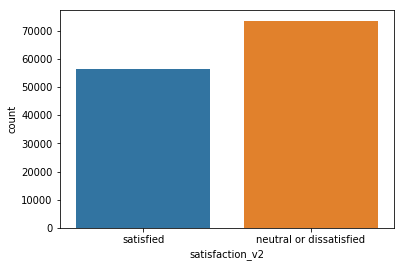

```python
sns.countplot(x= 'satisfaction_v2', data = airline_data)
```

**Counting the number of Loyal & Disoyal customers in the survey**

A very large number of Loyal customers have contributed to this survey as compared to the ones labelled disloyal

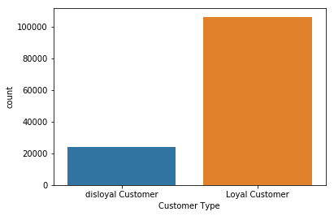

```python
sns.countplot(x= 'Customer Type', data = airline_data)
```

**Counting the Type of travels considered in the survey**

The survey consists of more number of business travels trips than the personal travels

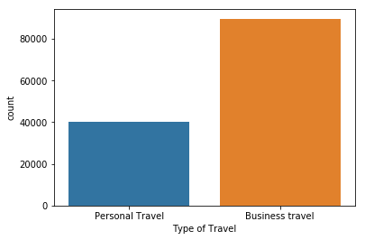

```python
sns.countplot(x= 'Type of Travel', data = airline_data)
```

**Counting the number of customers surveyed from each of the travel classes**

Almost equal number of customers from Economy and Business class were surveyed, along with a very small nmuber of Economy Plus customers

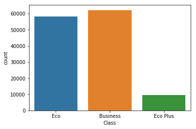

```python
sns.countplot(x= 'Class', data = airline_data)
```

**Ratings for Leg Room Service provided by the airline**

Most customers have rated the leg room space on the higher side

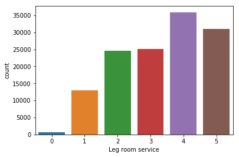

```python
sns.countplot(x= 'Leg room service', data = airline_data)
```

**Ratings for Leg Room Service for different travel Class**

We observe that the high leg-room ratings are given mostly by business class passesgers

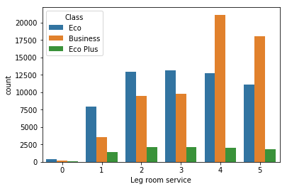

```python
sns.countplot(x= 'Leg room service', data = airline_data,hue='Class')
```

**Ratings for In-flight wifi service**

Wifi service has ratings ranging over all the scores, mostly in 2 and 3. There is room for improvement in the wifi service.

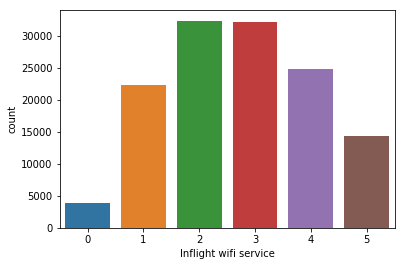

```python
sns.countplot(x= 'Inflight wifi service', data = airline_data)
```

**Ratings for Food and Drinks**

Maximum passengers have given a high rating for food and drink.

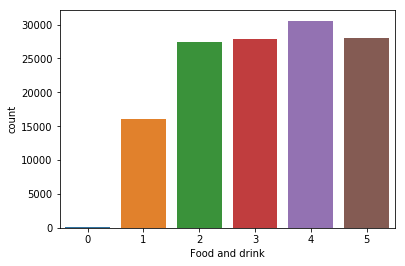

```python
sns.countplot(x= 'Food and drink', data = airline_data)
```

**Ratings for Food and Drinks, according to Class**

We see that more business class passengers give a high rating tio the food and drink service, however not a very large difference is seen

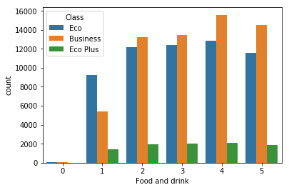

```python
sns.countplot(x= 'Food and drink', data = airline_data, hue='Class')
```

**Ratings for Seat Comfort**

Maximum passengers have given a high rating for seat comfort

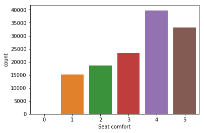

```python
sns.countplot(x= 'Seat comfort', data = airline_data)
```

**Ratings for Seat Comfort according to Class**

We see much more business class passengers giving high ratings of 4 and 5. The seat comfort for Economy class can be improved

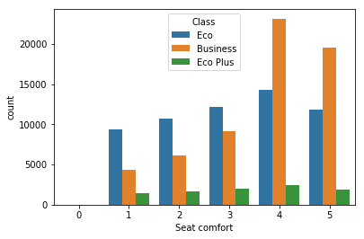

```python
sns.countplot(x= 'Seat comfort', data = airline_data, hue='Class')
```

**Ratings for Baggage Handling**

We see more business class passengers giving high ratings of 4 and 5.

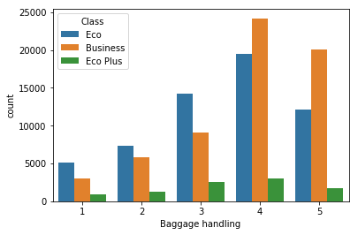

```python
sns.countplot(x= 'Baggage handling', data = airline_data, hue='Class')
```

**Ratings for Inflight Service**

A large number of passengers rated it 4 and 5.

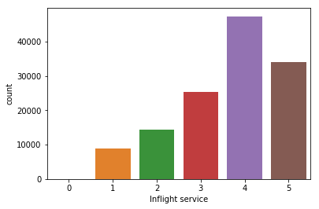

```python
sns.countplot(x= 'Inflight service', data = airline_data)
```

**Ratings for Inflight Service according to Class**

Large number of Business Classpassengers have rated inflight service 4 and 5.

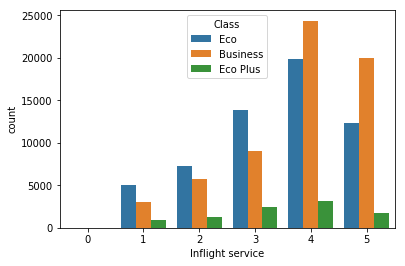

```python
sns.countplot(x= 'Inflight service', data = airline_data, hue='Class')
```